# Assignment 2: Linear regression

```
# Meri Korhonen 9.11.2021
# Script to fit linear regression model

# read the data set and check the structure
df = read.csv("data/learning2014.csv")
str(df)

# access the GGally and ggplot2 libraries
library(GGally)
library(ggplot2)

# create a summary plot matrix of all variables with ggpairs()
#ggpairs(df[-1], lower = list(combo = wrap("facethist", bins = 20)))
# create a more advanced plot matrix with ggpairs()
ggpairs(df[-1], mapping = aes(col = gender, alpha = 0.3), lower = list(combo = wrap("facethist", bins = 20)))

# --- PLOT SCATTER PLOTS WITH LINEAR REGRESSION (these plots not included in the final analysis)

# initialize plot with data and aesthetic mapping
p1 <- ggplot(df, aes(x = stra, y = Points, col = gender))
# define the visualization type (points)
p2 <- p1 + geom_point()
# add a regression line
p3 <- p2 + geom_smooth(method = "lm")
# add a main title and draw the plot
p4 <- p3 + ggtitle("Student's strategic approach versus exam points")
# draw the plot
p4

# another scatter plot (no gender distinction) of points versus attitude
qplot(attitude, Points, data = df) + geom_smooth(method = "lm")

# --- FIT LINEAR MODEL

# create a regression model with multiple explanatory variables
my_model <- lm(Points ~ attitude + stra + surf, data = df)
# print out a summary of the model
summary(my_model)

# see the results of the model with only attitude as explanatory variable
my_model2 <- lm(Points ~ attitude, data = df)
summary(my_model2)

# draw diagnostic plots using the plot() function. Choose the plots 1, 2 and 5
par(mfrow = c(2,2))
plot(my_model2, which = c(1,2,5))
```

**Introducing the data set**

The analyzed data consists of seven variables associated with people’s learning habits. Collected background information includes a person’s gender and age. Learning habits were measured by verbal questions and measured with a scale from 0 to 5. The variables associated with learning are attitude as well as deep, strategic and surface learning skills. The learning outcome is measured as exam points. In total, learning processes of 166 persons were studied.

Figure 1 shows summary of the relationships and distributions of all studied variables. Of the studied persons majority are female (red) and around one third male (blue). In general the variables are nearly normally distributed, although some tails exist especially in data describing males. This may be due to the smaller group size, which allows the peripheral values to influence the distribution. The distribution in age is close to lognormal with most persons belonging to the age group 19-21.

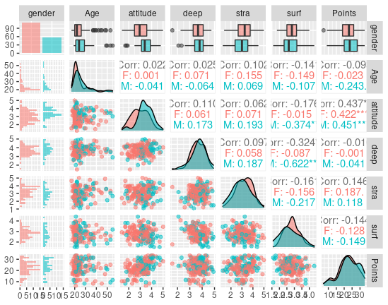

Figure 1. Summary of all variables in the study.

**Modeling the data**

Multiple linear regression model is fitted to the data in order to see whether exam points can be predicted by persons’ attitude, strategic and surface learning skills. The results are summarized in Table 1. The multiple R-squared of the fit is 0.21, indicating that 21 % of the variety in exam points can be attributed to these variables.

Of the three explanatory variables only attitude has P-value close to zero, indicating statistically significant correlation with exam points. According to the P-value, strategic and surface learning skills have no significant influence on success in exam. To confirm this, it is necessary to look at the standardized regression coefficients. They are 0.42, 0.11 and -0.05 for attitude, strategic and surface learning skills, respectively. It is seen that the standardized regression coefficients for attitude and strategic learning skills have the same order of magnitude. Therefore the strategic learning skills could potentially have importance for success in exam. However, as attitude is still clearly the most important predictor, both strategic and surface learning skills will be excluded from further analysis and I will only focus on attitude.

Table 1. Summary of results from fitting multiple linear regression model to exam points with attitude, strategic and surface learning skills as explanatory variables. (Residual standard error = 5.296, DF = 162, Multiple R-squared = 0.2074, Adjusted R-squared = 0.1927, F-statistic = 14.13, p-value = 3.156e-08)

|  | Estimate | Std. Error | T value | Pr(>\|t\|) |
| --- | --- | --- | --- | --- |
| Intercept | 11.0171 | 3.6837 | 2.991 | 0.00322 ** |
| attitude | 3.3952 | 0.5741 | 5.913 | 1.93e-08 *** |
| strategic | 0.8531 | 0.5416 | 1.575 | 0.11716 |
| surface | -0.5861 | 0.8014 | -0.731 | 0.46563 |

In Table 2 the results of the linear regression fit with attitude as explanatory variable are summarized. Now the R-squared is 0.19, indicating that 19 % of the variety in exam points can be predicted with attitude. The adjusted R-squared is also 0.19, which is equal to the adjusted R-squared obtained with all three explanatory variables. Therefore it can be concluded that the strategic and surface learning skills do not increase, or increase only very slightly, the capability of the model to predict exam points.

Table 2. Summary of results from fitting linear regression model to exam points with attitude as explanatory variable. (Residual standard error = 5.32, DF = 164, Multiple R-squared = 0.1906, Adjusted R-squared = 0.1856, F-statistic = 38.61, p-value = 4.119e-09)

|  | Estimate | Std. error | T value | Pr(>\|t\|) |
| --- | --- | --- | --- | --- |
| Intercept | 11.6372 | 1.8303 | 6.358 | 1.95e-09 *** |
| attitude | 3.5255 | 0.5674 | 6.214 | 4.12e-09 *** |

**Diagnostics of the linear fit**

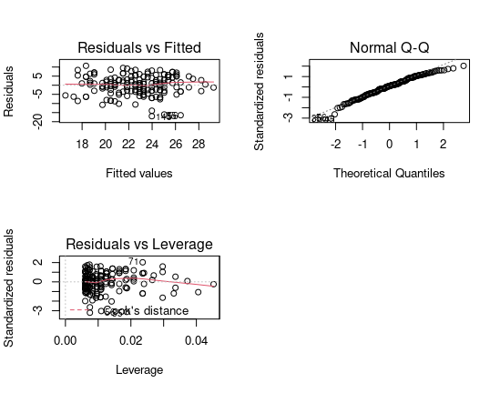

Figure 2. Diagnostics of the linear fit with attitude as explanatory variable.